# Lecture 14 - Generalized Linear Models Activity

Author

Bill Perry

# THE SETUP

```r
# Load required packages
# install.packages("ResourceSelection")
# install.packages("pscl")
library(janitor)
library(pscl)
library(tinytable)
library(skimr)
library(performance)
library(ResourceSelection)
library(car)
library(emmeans)
library(DHARMa)
library(MASS)
library(broom)
library(flextable)
library(parameters)
library(patchwork)  # For combining plots
library(faraway)  # For gala dataset
library(tidyverse)


# Set options
options(scipen = 999)
```

# Lecture 14: Generalized Linear Models Activity

## Generalized Linear Models (GLMs) extend linear models to handle different types of response variables:

- **Normal distribution**: Continuous data (like regular ANOVA/regression)
- **Poisson distribution**: Count data
- **Binomial distribution**: Binary data (presence/absence, success/failure)
- **Gamma distribution**: Positive continuous data
- **Negative binomial**: Overdispersed count data

## The Three Components of GLMs

1. **Random component**: The response variable and its probability distribution
2. **Systematic component**: The predictor variables (continuous or categorical)
3. **Link function**: Connects expected value of Y to predictor variables

# How to approach the problem

- **What is the question?**
  - unclear data mining can lead to lost time
- **Data Variable type**: what does the data look like - types of variable read in
- **Data Completeness**: Is there a lot of sparcity
- **Data Structure**: what does the data look like graphically
- **Model Choice:** what is the right model to analyze the data to answer your question
- **Model Run:** run model - summary
- **Model Assumptions**: test early before you get excited and bend the rules
- **Model Statistics** : run the final stats
- Model Followup tests: post F pairwise comparisons or others
- **Graphical display of results:** highlighting the data and statistics

# Part 1: Gaussian GLM

The simplest form of GLM uses a normal (Gaussian) distribution with an identity link function. This is equivalent to standard ANOVA

Let’s compare a standard linear model and a Gaussian GLM

## Island Biogeography Data

The `gala` dataframe from the `faraway` package contains data on 30 Galapagos islands, testing MacArthur-Wilson’s theory of island biogeography.

- **Variables in the dataframe:**
  - `spp`Number of plant species (count data)
  - `endemics`Number of endemic species (count data)
  - `area`Island area (km²)
  - `elevation -`Maximum elevation (m)
  - `Nearest` - Distance to nearest island (km)
  - `scruz` - Distance to Santa Cruz island (km)
  - `adjacent` - area of adjacent island (km²)

## The data - variable types

```r
# Create a categorical variable for demonstration
g_df <- gala %>% clean_names() %>%
  rename(spp = species) %>%
  mutate(size_cat = case_when(
    area < 1 ~ "small",
    area >= 1 & area < 100 ~ "medium",
    area >= 100 ~ "large"
  ),
  size_cat = factor(size_cat, levels = c("small", "medium", "large")))

g_df <- g_df %>% filter(area < 3000)

head(g_df %>% dplyr::select(-scruz, -adjacent), 10)
```

```
             spp endemics  area elevation nearest size_cat
Baltra        58       23 25.09       346     0.6   medium
Bartolome     31       21  1.24       109     0.6   medium
Caldwell       3        3  0.21       114     2.8    small
Champion      25        9  0.10        46     1.9    small
Coamano        2        1  0.05        77     1.9    small
Daphne.Major  18       11  0.34       119     8.0    small
Daphne.Minor  24        0  0.08        93     6.0    small
Darwin        10        7  2.33       168    34.1   medium
Eden           8        4  0.03        71     0.4    small
Enderby        2        2  0.18       112     2.6    small
```

## Data completeness

### The Formula for Geometric Mean (GM)

- The geometric mean is the *n*-th root of the *product* of *n* numbers.<sup>2</sup>
- For a set of numbers $x_1, x_2, ..., x_n$, the formula is:
- $GM = \sqrt[n]{x_1 \cdot x_2 \cdot \dots \cdot x_n}$

```r
g_df %>% skim()
```

Data summary

| Name | Piped data |
| --- | --- |
| Number of rows | 29 |
| Number of columns | 8 |
| _______________________ |  |
| Column type frequency: |  |
| factor | 1 |
| numeric | 7 |
| ________________________ |  |
| Group variables | None |

**Variable type: factor**

| skim_variable | n_missing | complete_rate | ordered | n_unique | top_counts |
| --- | --- | --- | --- | --- | --- |
| size_cat | 0 | 1 | FALSE | 3 | med: 12, sma: 11, lar: 6 |

**Variable type: numeric**

| skim_variable | n_missing | complete_rate | mean | sd | p0 | p25 | p50 | p75 | p100 | hist |
| --- | --- | --- | --- | --- | --- | --- | --- | --- | --- | --- |
| spp | 0 | 1 | 76.21 | 105.25 | 2.00 | 12.00 | 40.00 | 93.00 | 444.00 | ▇▂▁▁▁ |
| endemics | 0 | 1 | 23.93 | 25.05 | 0.00 | 7.00 | 17.00 | 30.00 | 95.00 | ▇▅▁▁▁ |
| area | 0 | 1 | 109.72 | 235.81 | 0.01 | 0.23 | 2.33 | 58.27 | 903.82 | ▇▁▁▁▁ |
| elevation | 0 | 1 | 321.86 | 343.31 | 25.00 | 94.00 | 186.00 | 367.00 | 1494.00 | ▇▂▂▁▁ |
| nearest | 0 | 1 | 10.38 | 14.42 | 0.20 | 1.10 | 3.30 | 10.70 | 47.40 | ▇▁▁▂▁ |
| scruz | 0 | 1 | 57.97 | 69.01 | 0.00 | 10.70 | 47.40 | 85.90 | 290.20 | ▇▃▁▁▁ |
| adjacent | 0 | 1 | 248.22 | 876.89 | 0.03 | 0.52 | 2.33 | 58.27 | 4669.32 | ▇▁▁▁▁ |

## Data graphically

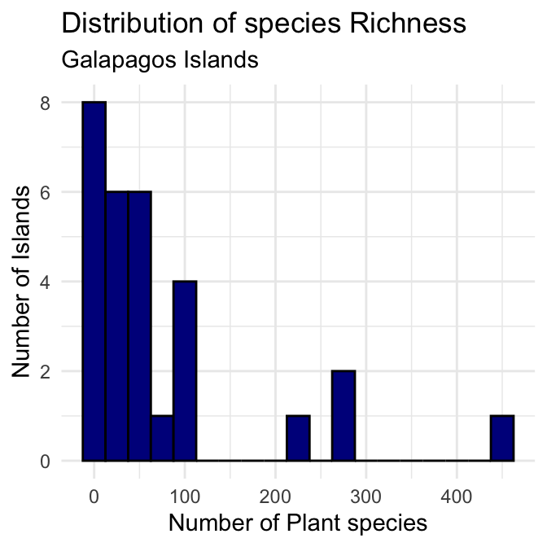

```r
#| message: false
#| warning: false
#| paged-print: false

ggplot(g_df, aes(x = spp)) +
  geom_histogram(binwidth = 25, fill = "darkblue", color = "black") +
  labs(title = "Distribution of species Richness",
       subtitle = "Galapagos Islands",
       x = "Number of Plant species",
       y = "Number of Islands") +
  theme_minimal()
```

## Data graphically as size categories

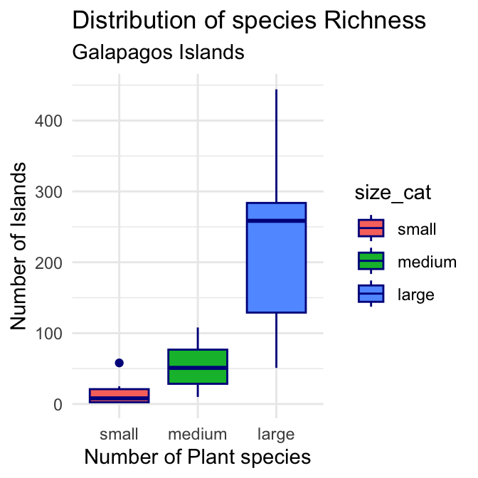

```r
ggplot(g_df, aes(x = size_cat, y = spp, fill = size_cat)) +
  geom_boxplot(color = "darkblue") +
  labs(title = "Distribution of species Richness",
       subtitle = "Galapagos Islands",
       x = "Number of Plant species",
       y = "Number of Islands") +
  theme_minimal()
```

# GLM with Gaussian (Normal) Distribution: Setup

The simplest form of GLM uses a normal (Gaussian) distribution with an identity link function. This is equivalent to standard linear model

Let’s compare a standard linear model and a Gaussian GLM using the Galapagos dataset, modeling endemic species richness by island size category.

## Linear model the old way

```r
# Fit a standard linear model
lm_model <- lm(endemics ~ size_cat, data = g_df)
summary(lm_model)
```

```
Call:
lm(formula = endemics ~ size_cat, data = g_df)

Residuals:
    Min      1Q  Median      3Q     Max
-39.000  -4.636  -0.667   6.333  33.000

Coefficients:
               Estimate Std. Error t value     Pr(>|t|)
(Intercept)       5.636      4.236   1.331       0.1948
size_catmedium   16.030      5.864   2.734       0.0111 *
size_catlarge    56.364      7.130   7.905 0.0000000221 ***
---
Signif. codes:  0 '***' 0.001 '**' 0.01 '*' 0.05 '.' 0.1 ' ' 1

Residual standard error: 14.05 on 26 degrees of freedom
Multiple R-squared:  0.708, Adjusted R-squared:  0.6855
F-statistic: 31.51 on 2 and 26 DF,  p-value: 0.0000001124
```

## The ANOVA model

```r
Anova(lm_model, type = 3 )
```

```
Anova Table (Type III tests)

Response: endemics
             Sum Sq Df F value       Pr(>F)
(Intercept)   349.5  1  1.7707       0.1948
size_cat    12438.6  2 31.5135 0.0000001124 ***
Residuals    5131.2 26
---
Signif. codes:  0 '***' 0.001 '**' 0.01 '*' 0.05 '.' 0.1 ' ' 1
```

## The Gaussian GLM model

```r
# Fit a Gaussian GLM
gauss_model <- glm(endemics ~ size_cat,  data = g_df,
                       family = gaussian(link = "identity"))

summary(gauss_model)
```

```
Call:
glm(formula = endemics ~ size_cat, family = gaussian(link = "identity"),
    data = g_df)

Coefficients:
               Estimate Std. Error t value     Pr(>|t|)
(Intercept)       5.636      4.236   1.331       0.1948
size_catmedium   16.030      5.864   2.734       0.0111 *
size_catlarge    56.364      7.130   7.905 0.0000000221 ***
---
Signif. codes:  0 '***' 0.001 '**' 0.01 '*' 0.05 '.' 0.1 ' ' 1

(Dispersion parameter for gaussian family taken to be 197.3543)

    Null deviance: 17569.9  on 28  degrees of freedom
Residual deviance:  5131.2  on 26  degrees of freedom
AIC: 240.4

Number of Fisher Scoring iterations: 2
```

## GLM ANOVA

```r
Anova(gauss_model, type = "III", test = "F")
```

```
Analysis of Deviance Table (Type III tests)

Response: endemics
Error estimate based on Pearson residuals

           Sum Sq Df F values       Pr(>F)
size_cat  12438.6  2   31.514 0.0000001124 ***
Residuals  5131.2 26
---
Signif. codes:  0 '***' 0.001 '**' 0.01 '*' 0.05 '.' 0.1 ' ' 1
```

## Assumption Tests of Both Models

### Linear model assumptions

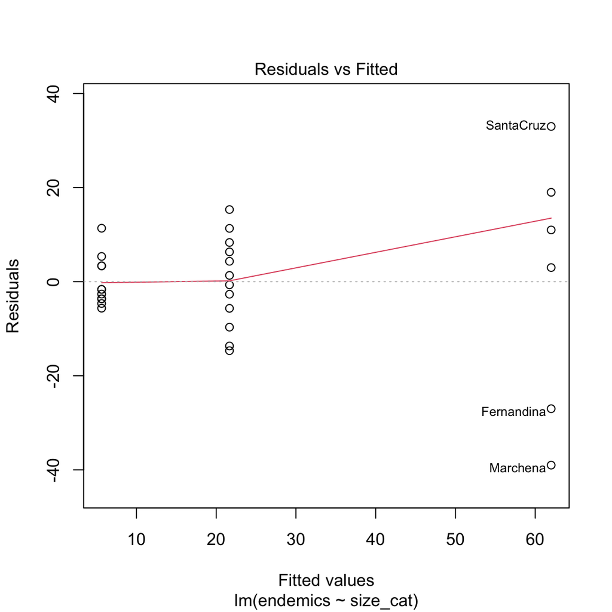

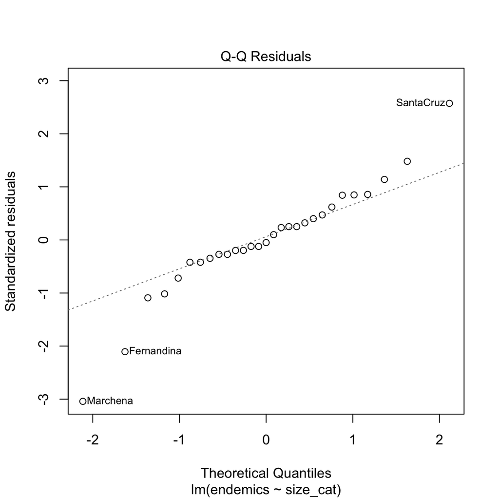

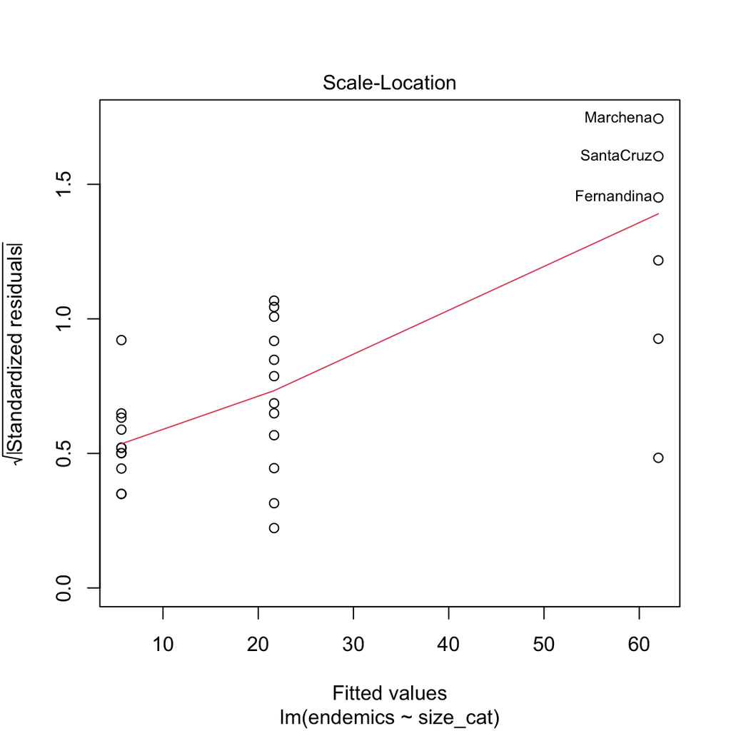

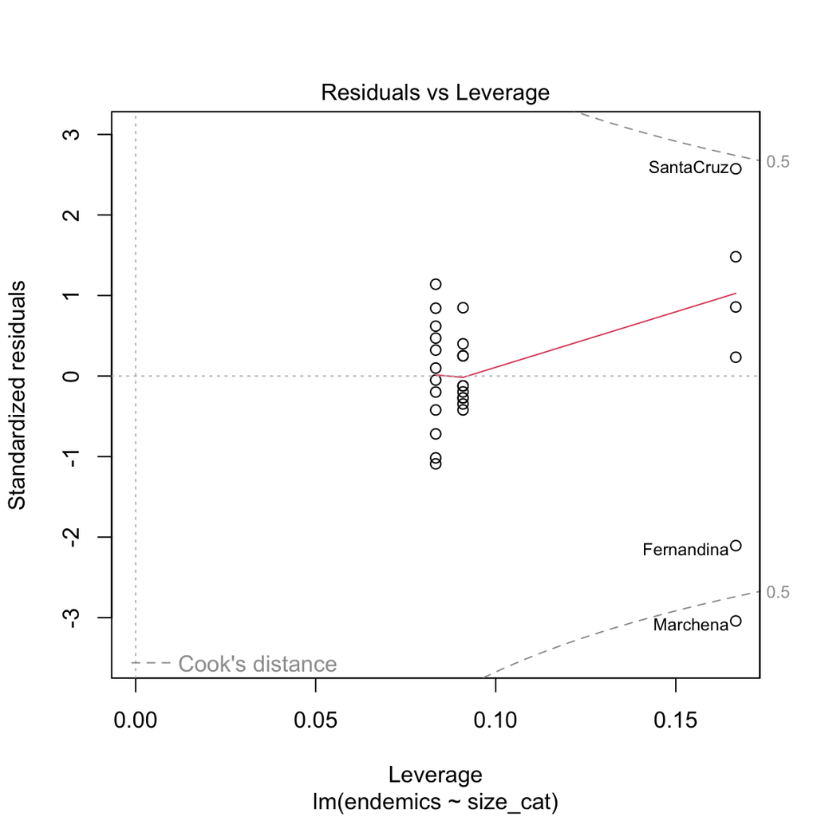

```r
# Create diagnostic plots
par(mfrow = c(1, 1))
plot(lm_model)
```

```r
par(mfrow = c(1, 1))
```

### GLM ASSUMPTIONS

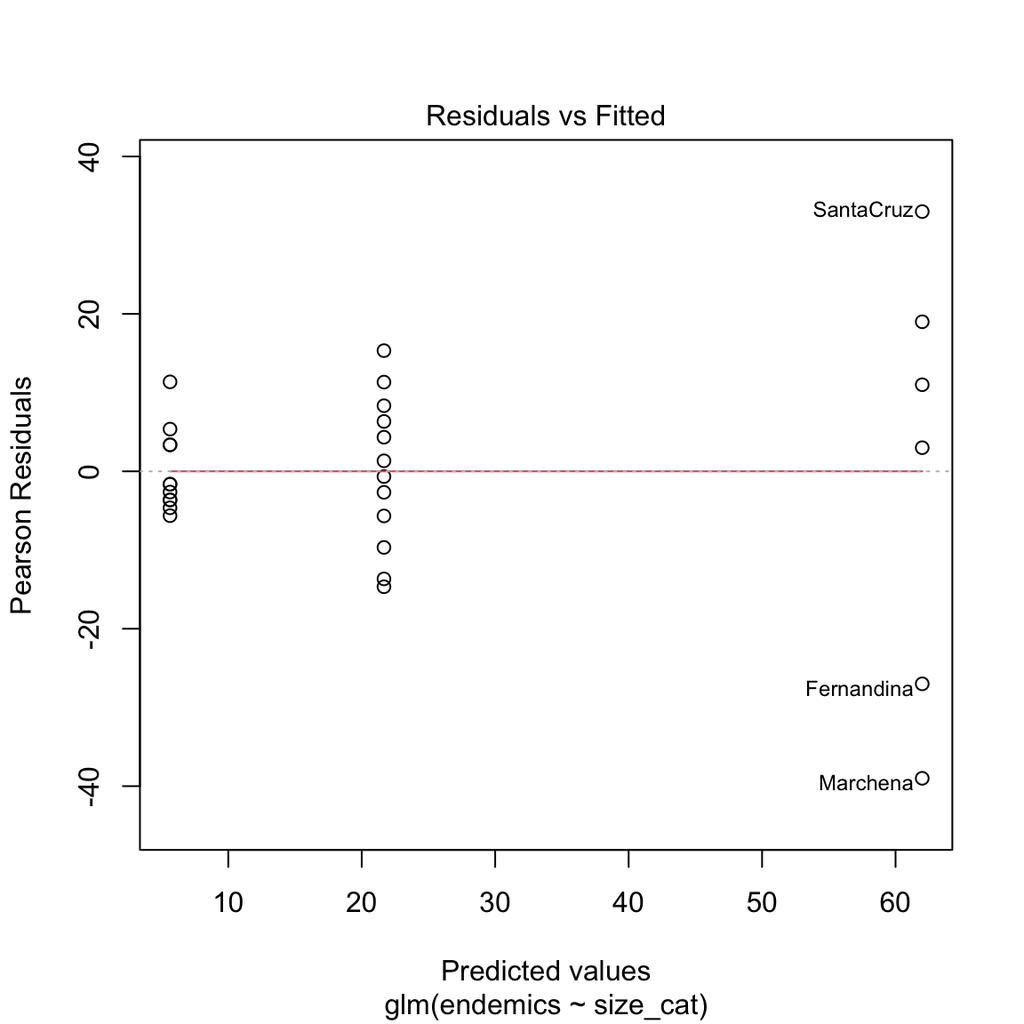

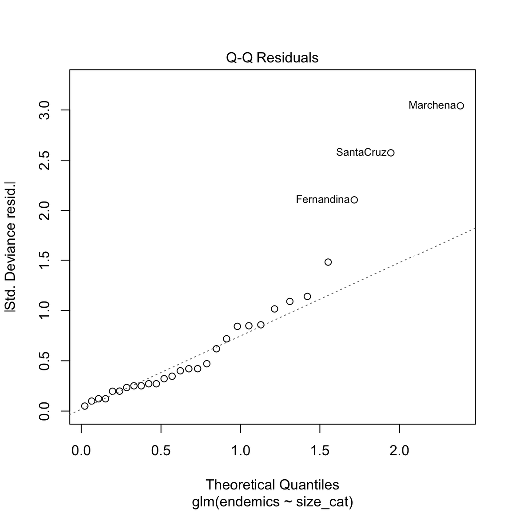

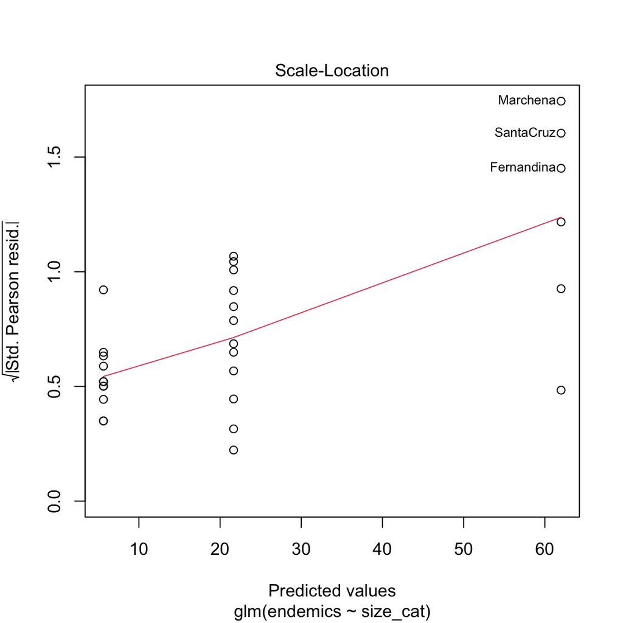

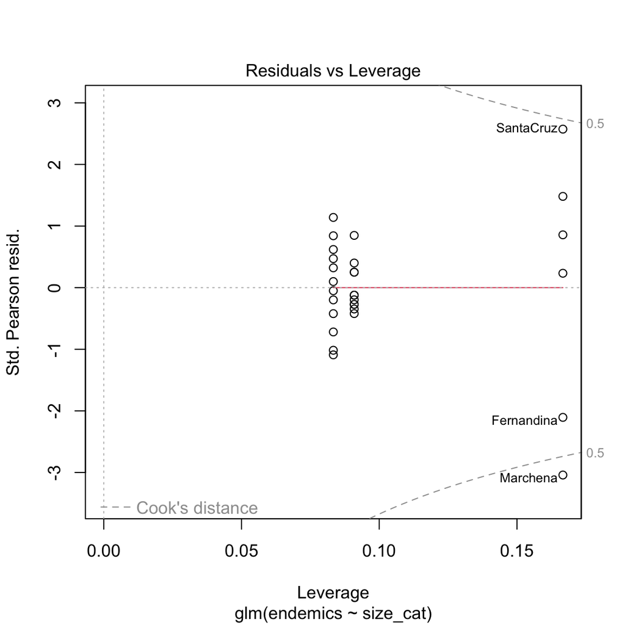

```r
# Create diagnostic plots
# par(mfrow = c(2, 2))
plot(gauss_model)
```

```r
# par(mfrow = c(1, 1))
```

### Shapiro Wilk Test Linear Model

```r
shapiro.test(residuals(lm_model))
```

```
    Shapiro-Wilk normality test

data:  residuals(lm_model)
W = 0.94396, p-value = 0.1273
```

### Shapiro Test Gaussian Model

```r
shapiro.test(residuals(gauss_model))
```

```
    Shapiro-Wilk normality test

data:  residuals(gauss_model)
W = 0.94396, p-value = 0.1273
```

## Levenes Test - this is why a Poisson Model fits

```r
leveneTest(endemics ~ size_cat,  data = g_df)
```

```
Levene's Test for Homogeneity of Variance (center = median)
      Df F value   Pr(>F)
group  2  7.9881 0.001975 **
      26
---
Signif. codes:  0 '***' 0.001 '**' 0.01 '*' 0.05 '.' 0.1 ' ' 1
```

## Dharma Assumption Test

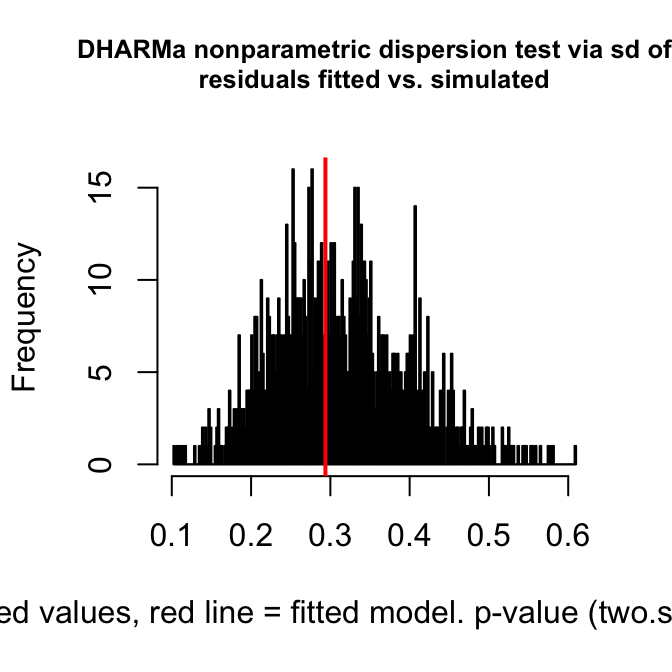

```
    DHARMa nonparametric dispersion test via sd of residuals fitted vs.
    simulated

data:  simulationOutput
dispersion = 0.93779, p-value = 0.882
alternative hypothesis: two.sided
```

```r
# 1. Simulate residuals
# (This is the standard first step for all DHARMa diagnostics)
sim_gauss_res <- simulateResiduals(fittedModel = gauss_model, n = 1000)

# 2. Test for dispersion
# This will provide a p-value and the ratio
testDispersion(sim_gauss_res)
```

[figure not shown]

```r
# Plot diagnostic plots
plot(sim_gauss_res)
```

## Emmeans Linear Model

```r
# Calculate estimated marginal means
lm_emmeans <- emmeans(lm_model, ~ size_cat)
lm_emmeans
```

```
 size_cat emmean   SE df lower.CL upper.CL
 small      5.64 4.24 26    -3.07     14.3
 medium    21.67 4.06 26    13.33     30.0
 large     62.00 5.74 26    50.21     73.8

Confidence level used: 0.95
```

## Emmeans GLM Mode

```r
# Calculate estimated marginal means
gauss_emmeans <- emmeans(gauss_model, ~ size_cat)
gauss_emmeans
```

```
 size_cat emmean   SE df lower.CL upper.CL
 small      5.64 4.24 26    -3.07     14.3
 medium    21.67 4.06 26    13.33     30.0
 large     62.00 5.74 26    50.21     73.8

Confidence level used: 0.95
```

### Pairs LM

```r
# # Pairwise comparisons with Sidak correction
lm_pairs <- pairs(lm_emmeans, adjust = "sidak")
lm_pairs
```

```
 contrast       estimate   SE df t.ratio p.value
 small - medium    -16.0 5.86 26  -2.734  0.0330
 small - large     -56.4 7.13 26  -7.905  <.0001
 medium - large    -40.3 7.02 26  -5.742  <.0001

P value adjustment: sidak method for 3 tests
```

### Pairs GLM

```r
# # Pairwise comparisons with Sidak correction
gauss_pairs <- pairs(gauss_emmeans, adjust = "sidak")
gauss_pairs
```

```
 contrast       estimate   SE df t.ratio p.value
 small - medium    -16.0 5.86 26  -2.734  0.0330
 small - large     -56.4 7.13 26  -7.905  <.0001
 medium - large    -40.3 7.02 26  -5.742  <.0001

P value adjustment: sidak method for 3 tests
```

### Plot of GLM

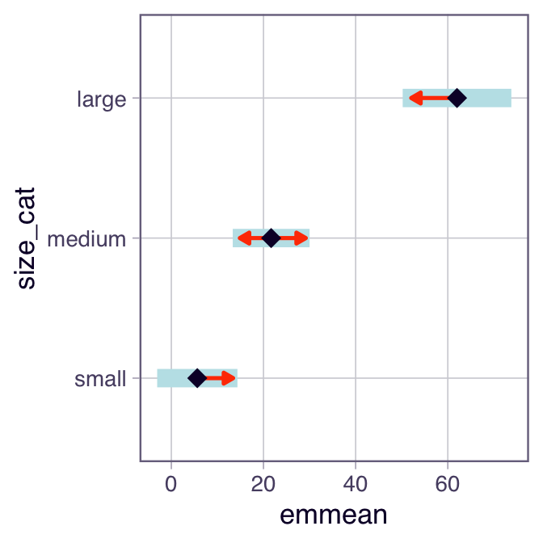

```r
plot(gauss_emmeans, comparisons = TRUE)
```

# GLM ANOVA with Poisson Distribution

## Fit Poisson GLM with size_cat as predictor

```r
poiss_model <- glm(spp ~ size_cat,
                          data = g_df,
                          family = poisson(link = "log"))
summary(poiss_model)
```

```
Call:
glm(formula = spp ~ size_cat, family = poisson(link = "log"),
    data = g_df)

Coefficients:
               Estimate Std. Error z value Pr(>|z|)
(Intercept)     2.67101    0.07930   33.68   <2e-16 ***
size_catmedium  1.33784    0.08833   15.15   <2e-16 ***
size_catlarge   2.77429    0.08372   33.14   <2e-16 ***
---
Signif. codes:  0 '***' 0.001 '**' 0.01 '*' 0.05 '.' 0.1 ' ' 1

(Dispersion parameter for poisson family taken to be 1)

    Null deviance: 3031.18  on 28  degrees of freedom
Residual deviance:  898.03  on 26  degrees of freedom
AIC: 1057.2

Number of Fisher Scoring iterations: 5
```

## GLM with Poisson Distribution: Setup

**Does island size category, as a whole, have a statistically significant effect on the number of plant species?**

- `test = "LR"`: important part!
  - normal ANOVA (with a Gaussian/normal distribution) test is an F-test.
  - GLM (like Poisson) can’t use F-test in the same way
    - use a Likelihood Ratio (LR) test
    - LR test statistically compares fit of full model (the one with size_cat) to simpler null model (one without size_cat)
    - LR test tells us if it is significant

```r
Anova(poiss_model, type = "III", test = "LR")
```

```
Analysis of Deviance Table (Type III tests)

Response: spp
         LR Chisq Df Pr(>Chisq)
size_cat   2133.2  2  < 2.2e-16 ***
---
Signif. codes:  0 '***' 0.001 '**' 0.01 '*' 0.05 '.' 0.1 ' ' 1
```

## Let’s check for overdispersion, which is common in count data:

- Should be close to 1 for a well-fitting Poisson model
- If > 1.5, may indicate overdispersion
  - **What is Underdispersion?**
    - In a Poisson model, we expect the variance to equal the mean. The dispersion parameter measures the ratio of observed variance to expected variance:
      - **Dispersion ≈ 1**: Good fit (variance = mean, as Poisson assumes)
      - **Dispersion > 1**: Overdispersion (variance > mean)
      - **Dispersion < 1**: **Underdispersion** (variance < mean)
  - a dispersion parameter this large is a warning
  - our data more variable than a Poisson model expects
  - use a Negative Binomial model

```r
# Pass your model to the function
performance::check_overdispersion(poiss_model)
```

```
# Overdispersion test

       dispersion ratio =  33.525
  Pearson's Chi-Squared = 871.642
                p-value = < 0.001
```

```
Overdispersion detected.
```

### DHARMA assumption plots

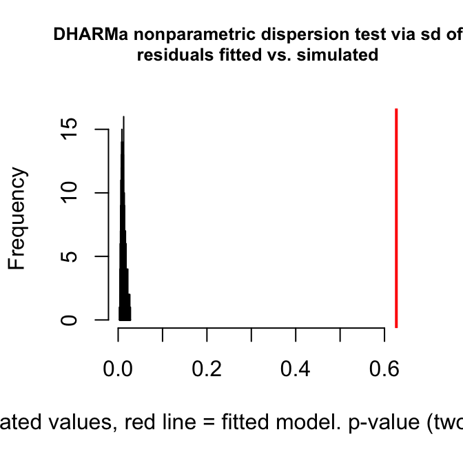

```
    DHARMa nonparametric dispersion test via sd of residuals fitted vs.
    simulated

data:  simulationOutput
dispersion = 55.559, p-value < 2.2e-16
alternative hypothesis: two.sided
```

```r
# 1. Simulate residuals
# (This is the standard first step for all DHARMa diagnostics)
sim_res <- simulateResiduals(fittedModel = poiss_model, n = 1000)

# 2. Test for dispersion
# This will provide a p-value and the ratio
testDispersion(sim_res)
```

[figure not shown]

```r
# Plot diagnostic plots
plot(sim_res)
```

### WHY DOES THE SHAPIRO TEST NOT WORK???

this you should consider - well it shouldn’t but it does this time . dang it…

```r
shapiro.test(residuals(poiss_model))
```

```
    Shapiro-Wilk normality test

data:  residuals(poiss_model)
W = 0.98973, p-value = 0.9909
```

## Poisson GLM Emmeans

```r
# 1. Calculate Estimated Marginal Means (EMMs)
# type = "response" converts the log-means back to the "species count" scale
pois_emm <- emmeans(poiss_model,
                    specs = ~ size_cat,
                    type = "response")
print(pois_emm)
```

```
 size_cat  rate   SE  df asymp.LCL asymp.UCL
 small     14.5 1.15 Inf      12.4      16.9
 medium    55.1 2.14 Inf      51.0      59.4
 large    231.7 6.21 Inf     219.8     244.2

Confidence level used: 0.95
Intervals are back-transformed from the log scale
```

## POISSON GLM Pairs Plots

```r
# 2. Pairwise Comparisons
# Compares all pairs: Small-Medium, Small-Large, Medium-Large
pois_pairs <- pairs(pois_emm, adjust = "tukey")
print(pois_pairs)
```

```
 contrast        ratio      SE  df null z.ratio p.value
 small / medium 0.2624 0.02320 Inf    1 -15.146  <.0001
 small / large  0.0624 0.00522 Inf    1 -33.139  <.0001
 medium / large 0.2378 0.01120 Inf    1 -30.403  <.0001

P value adjustment: tukey method for comparing a family of 3 estimates
Tests are performed on the log scale
```

```r
# 3. Compact Letter Display (CLD)
# The easiest way to see the groupings
pois_cld <- multcomp::cld(pois_emm,
                          Letters = letters,
                          alpha = 0.05)
print(pois_cld)
```

```
 size_cat  rate   SE  df asymp.LCL asymp.UCL .group
 small     14.5 1.15 Inf      12.4      16.9  a
 medium    55.1 2.14 Inf      51.0      59.4   b
 large    231.7 6.21 Inf     219.8     244.2    c

Confidence level used: 0.95
Intervals are back-transformed from the log scale
P value adjustment: tukey method for comparing a family of 3 estimates
Tests are performed on the log scale
significance level used: alpha = 0.05
NOTE: If two or more means share the same grouping symbol,
      then we cannot show them to be different.
      But we also did not show them to be the same.
```

Poisson GLM Plot

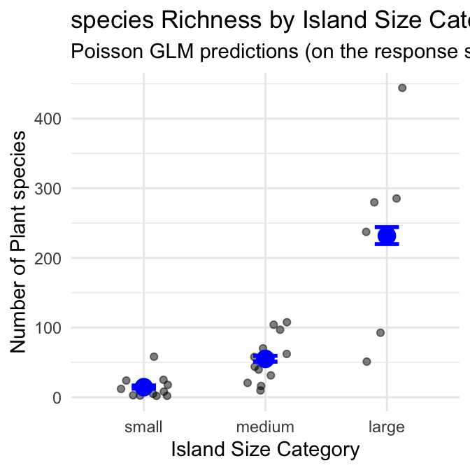

```r
# 1. Get the estimated means and CIs into a dataframe
emm_poiss_df <- as.data.frame(pois_emm)

# 2. Create visualization
ggplot() +
  # Plot raw data (jittered so we can see the points)
  geom_jitter(data = g_df,
              aes(x = size_cat, y = spp),
              width = 0.2, # Spreads points horizontally
              alpha = 0.5) +
  # Add estimated means (points)
  geom_point(data = emm_poiss_df,
             aes(x = size_cat, y = rate), # 'rate' is the mean
             size = 4, color = "blue") +
  # Add confidence intervals (error bars)
  geom_errorbar(data = emm_poiss_df,
                aes(x = size_cat,
                    ymin = asymp.LCL, # Lower Confidence Limit
                    ymax = asymp.UCL), # Upper Confidence Limit
                width = 0.2, color = "blue", linewidth = 1) +
  labs(title = "species Richness by Island Size Category",
       subtitle = "Poisson GLM predictions (on the response scale)",
       x = "Island Size Category",
       y = "Number of Plant species") +
  theme_minimal()
```

# Negative Binomial GLM ANOVA

[output not shown]

## Assumptions

[figure not shown]

```r
# 1. Simulate residuals
nb_sim_res <- simulateResiduals(fittedModel = nb_model)

# 2. Plot the diagnostics
plot(nb_sim_res)
```

### Note Shapiro test does not work

```r
shapiro.test(residuals(nb_model))
```

```
    Shapiro-Wilk normality test

data:  residuals(nb_model)
W = 0.94501, p-value = 0.1357
```

## Overdispersion

```r
# This will test if there is *still* significant overdispersion
check_overdispersion(nb_model)
```

```
# Overdispersion test

 dispersion ratio = 0.586
          p-value = 0.632
```

```
No overdispersion detected.
```

# ANOVA GLM Negative Binmial

```r
# Get the overall Anova (Type III Likelihood Ratio test)
nb_anova <- Anova(nb_model, type = "III", test = "LR")

print(nb_anova)
```

```
Analysis of Deviance Table (Type III tests)

Response: spp
         LR Chisq Df Pr(>Chisq)
size_cat   49.858  2  1.491e-11 ***
---
Signif. codes:  0 '***' 0.001 '**' 0.01 '*' 0.05 '.' 0.1 ' ' 1
```

```r
# 1. Calculate the Estimated Marginal Means on the "response" scale
nb_emmeans <- emmeans(nb_model, spec = ~ size_cat, type = "response")

print(nb_emmeans)
```

```
 size_cat response    SE  df asymp.LCL asymp.UCL
 small        14.5  3.57 Inf      8.91      23.5
 medium       55.1 12.50 Inf     35.27      86.0
 large       231.7 73.70 Inf    124.22     432.0

Confidence level used: 0.95
Intervals are back-transformed from the log scale
```

### Pairwise

```r
# 2. Run pairwise comparisons on those means
nb_pairs <- pairs(nb_emmeans)

print(nb_pairs)
```

```
 contrast        ratio     SE  df null z.ratio p.value
 small / medium 0.2624 0.0881 Inf    1  -3.984  0.0002
 small / large  0.0624 0.0251 Inf    1  -6.889  <.0001
 medium / large 0.2378 0.0929 Inf    1  -3.675  0.0007

P value adjustment: tukey method for comparing a family of 3 estimates
Tests are performed on the log scale
```

```r
# 3. Get the Compact Letter Display (CLD)
nb_cld  <- multcomp::cld(nb_emmeans, Letters = letters)

print(nb_cld)
```

```
 size_cat response    SE  df asymp.LCL asymp.UCL .group
 small        14.5  3.57 Inf      8.91      23.5  a
 medium       55.1 12.50 Inf     35.27      86.0   b
 large       231.7 73.70 Inf    124.22     432.0    c

Confidence level used: 0.95
Intervals are back-transformed from the log scale
P value adjustment: tukey method for comparing a family of 3 estimates
Tests are performed on the log scale
significance level used: alpha = 0.05
NOTE: If two or more means share the same grouping symbol,
      then we cannot show them to be different.
      But we also did not show them to be the same.
```

# Generalized Linear Models (GLMs) extend linear models to handle different types of response variables:

- Normal distribution: Continuous data (like regular ANOVA/regression)
- Poisson distribution: Count data
- Binomial distribution: Binary data (presence/absence, success/failure)
- Gamma distribution: Positive continuous data
- Negative binomial: Overdispersed count data

# Gaussian GLM (equivalent to simple linear regression)

The simplest form of GLM uses a normal (Gaussian) distribution with an identity link function. This is equivalent to a standard linear regression.

Let’s compare a standard linear model and a Gaussian GLM.

[figure not shown]

```r
# 1. Distribution of Endemic Species
p1 <- ggplot(g_df, aes(x = endemics)) +
  geom_histogram(binwidth = 10, fill = "darkblue", color = "black") +
  labs(title = "Distribution of Endemic Species",
       x = "Number of Endemic Species",
       y = "Number of Islands") +
  theme_minimal()

# 2. Distribution of All Species
p2 <- ggplot(g_df, aes(x = spp)) +
  geom_histogram(binwidth = 25, fill = "darkgreen", color = "black") +
  labs(title = "Distribution of All Species",
       x = "Number of Plant Species",
       y = "Number of Islands") +
  theme_minimal()

# 3. Endemics vs Area (for Gaussian model)
p3 <- ggplot(g_df, aes(x = area, y = endemics)) +
  geom_point() +
  geom_smooth(method = "lm", se = FALSE, color = "blue") +
  labs(title = "Endemic Species vs. Island Area",
       x = "Area (km²)",
       y = "Number of Endemic Species") +
  theme_minimal()

# 4. Species vs Area (for Poisson/NB models)
p4 <- ggplot(g_df, aes(x = area, y = spp)) +
  geom_point() +
  labs(title = "All Species vs. Island Area",
       x = "Area (km²)",
       y = "Number of Plant Species") +
  theme_minimal()

# Combine plots
(p1 + p2) / (p3 + p4)
```

# GLM with Gaussian (Normal) Distribution: Setup

We will model the continuous endemics variable as a function of the continuous area variable. This is a simple linear regression. We compare the lm() function with the glm() function using family = gaussian.

# The linear model summary

```r
# Fit a standard linear model
lm_reg_model <- lm(endemics ~ area, data = g_df)
summary(lm_reg_model)
```

```
Call:
lm(formula = endemics ~ area, data = g_df)

Residuals:
    Min      1Q  Median      3Q     Max
-34.690 -10.366  -2.612   6.528  43.733

Coefficients:
            Estimate Std. Error t value Pr(>|t|)
(Intercept) 14.36338    2.99342   4.798 5.24e-05 ***
area         0.08720    0.01168   7.468 4.93e-08 ***
---
Signif. codes:  0 '***' 0.001 '**' 0.01 '*' 0.05 '.' 0.1 ' ' 1

Residual standard error: 14.57 on 27 degrees of freedom
Multiple R-squared:  0.6738,    Adjusted R-squared:  0.6617
F-statistic: 55.77 on 1 and 27 DF,  p-value: 4.929e-08
```

# The ANOVA model

This table gives the F-statistic for the overall model, which in a simple linear regression, tests the same hypothesis as the t-test for the area slope.

```r
Anova(lm_reg_model, type = 3 )
```

```
Anova Table (Type III tests)

Response: endemics
             Sum Sq Df F value    Pr(>F)
(Intercept)  4887.1  1  23.024 5.237e-05 ***
area        11838.8  1  55.775 4.929e-08 ***
Residuals    5731.0 27
---
Signif. codes:  0 '***' 0.001 '**' 0.01 '*' 0.05 '.' 0.1 ' ' 1
```

# The Gaussian GLM model

Note the estimates and p-values are identical to the lm() output.

```r
# Fit a Gaussian GLM
gauss_reg_model <- glm(endemics ~ area,  data = g_df,
                   family = gaussian(link = "identity"))

summary(gauss_reg_model)
```

```
Call:
glm(formula = endemics ~ area, family = gaussian(link = "identity"),
    data = g_df)

Coefficients:
            Estimate Std. Error t value Pr(>|t|)
(Intercept) 14.36338    2.99342   4.798 5.24e-05 ***
area         0.08720    0.01168   7.468 4.93e-08 ***
---
Signif. codes:  0 '***' 0.001 '**' 0.01 '*' 0.05 '.' 0.1 ' ' 1

(Dispersion parameter for gaussian family taken to be 212.261)

    Null deviance: 17570  on 28  degrees of freedom
Residual deviance:  5731  on 27  degrees of freedom
AIC: 241.6

Number of Fisher Scoring iterations: 2
```

# GLM ANOVA

Again, this F-test is identical to the one from the lm() model.

```r
Anova(gauss_reg_model, type = "III", test = "F")
```

```
Analysis of Deviance Table (Type III tests)

Response: endemics
Error estimate based on Pearson residuals

          Sum Sq Df F values    Pr(>F)
area       11839  1   55.775 4.929e-08 ***
Residuals   5731 27
---
Signif. codes:  0 '***' 0.001 '**' 0.01 '*' 0.05 '.' 0.1 ' ' 1
```

# Assumption Tests of Both Models

The diagnostic plots for lm_model and gauss_model will be identical.

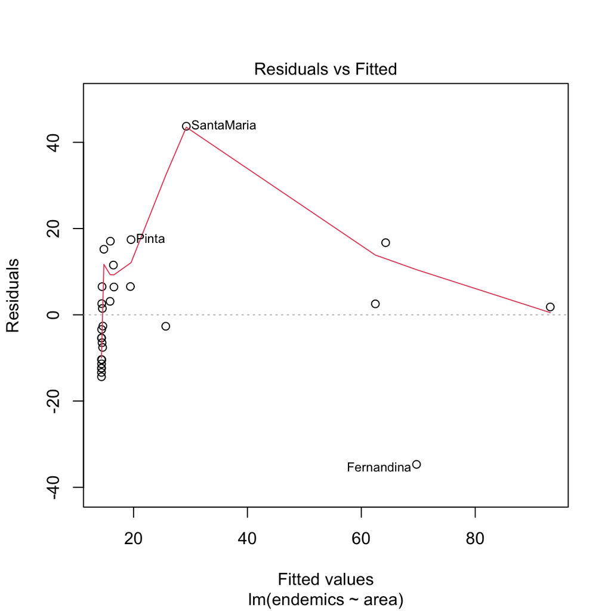

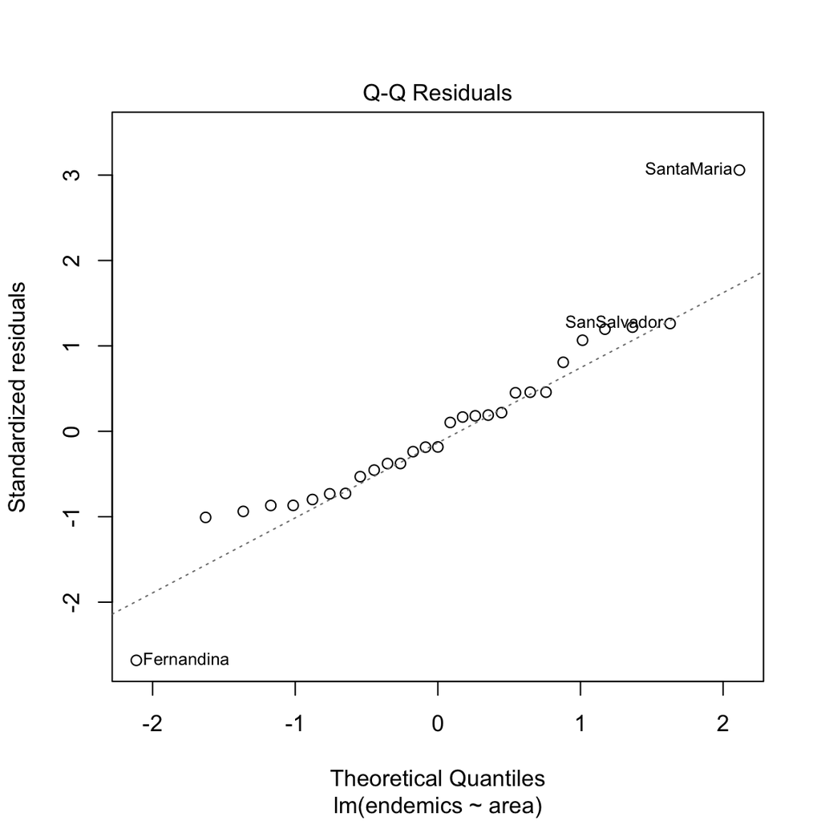

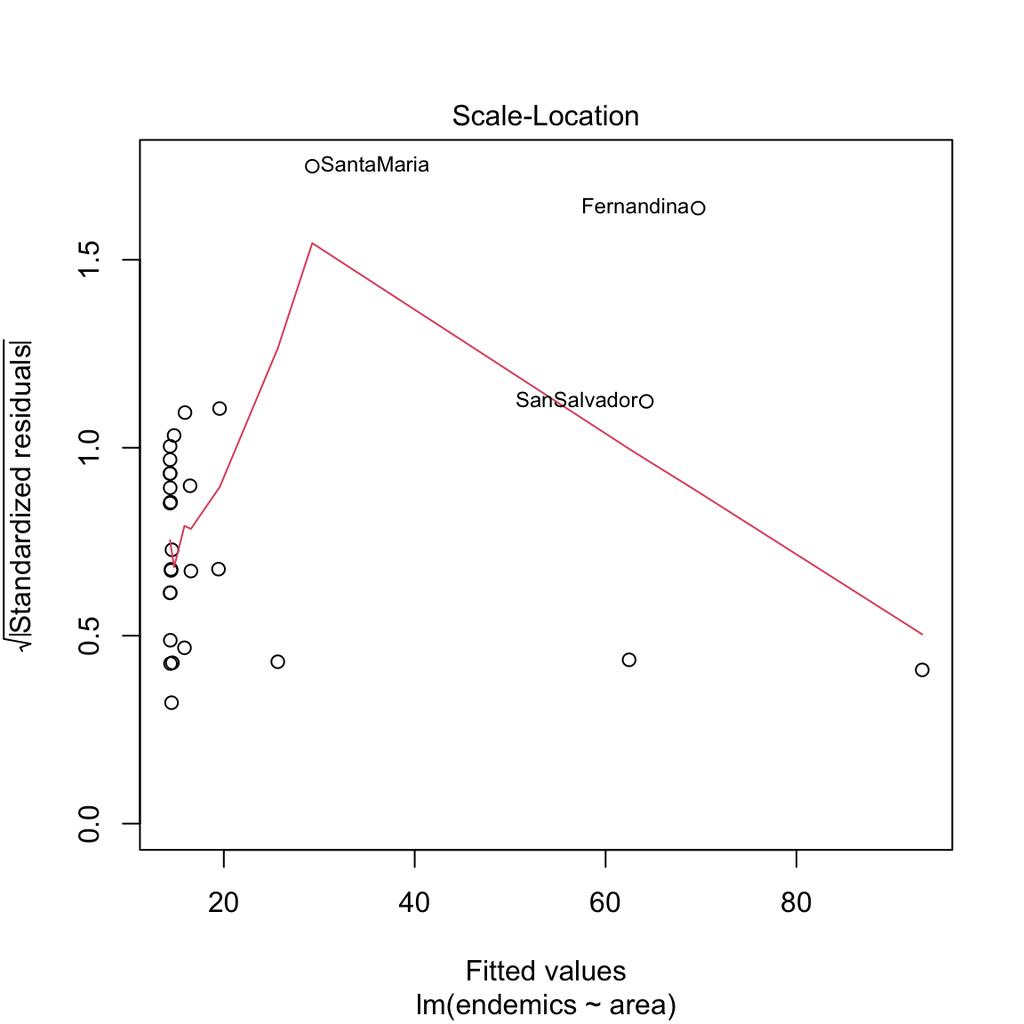

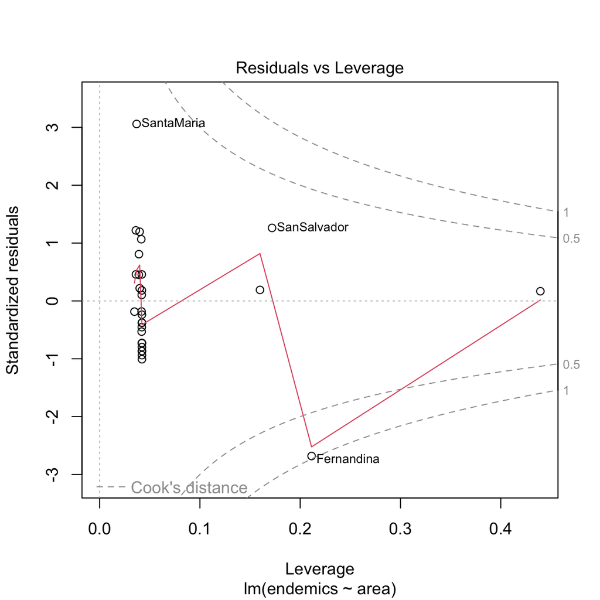

```r
# Create diagnostic plots for lm()
par(mfrow = c(1, 1))
plot(lm_reg_model)
```

```r
par(mfrow = c(1, 1))
```

# Shapiro-Wilk Test (Normality of Residuals)

```r
shapiro.test(residuals(lm_reg_model))
```

```
    Shapiro-Wilk normality test

data:  residuals(lm_reg_model)
W = 0.93735, p-value = 0.08547
```

```r
shapiro.test(residuals(gauss_reg_model))
```

```
    Shapiro-Wilk normality test

data:  residuals(gauss_reg_model)
W = 0.93735, p-value = 0.08547
```

# GLM Regression with Poisson Distribution

- Poisson GLMs are used when the response variable is count data.
- We will now model the total number of species (spp) as a function of island area.
- The Poisson distribution assumes the mean equals the variance.
- Key consideration: If variance > mean (overdispersion), we should use a negative binomial model instead.
- Fit Poisson GLM with area as predictor

```r
poiss_reg_model <- glm(spp ~ area,
                   data = g_df,
                   family = poisson(link = "log"))
summary(poiss_reg_model)
```

```
Call:
glm(formula = spp ~ area, family = poisson(link = "log"), data = g_df)

Coefficients:
             Estimate Std. Error z value Pr(>|z|)
(Intercept) 3.737e+00  3.022e-02  123.66   <2e-16 ***
area        2.693e-03  5.759e-05   46.76   <2e-16 ***
---
Signif. codes:  0 '***' 0.001 '**' 0.01 '*' 0.05 '.' 0.1 ' ' 1

(Dispersion parameter for poisson family taken to be 1)

    Null deviance: 3031.2  on 28  degrees of freedom
Residual deviance: 1229.5  on 27  degrees of freedom
AIC: 1386.6

Number of Fisher Scoring iterations: 5
```

# GLM with Poisson Distribution: ANOVA

Does island area, as a whole, have a statistically significant effect on the number of plant species? We use a Likelihood Ratio (LR) test.

```r
Anova(poiss_reg_model, type = "III", test = "LR")
```

```
Analysis of Deviance Table (Type III tests)

Response: spp
     LR Chisq Df Pr(>Chisq)
area   1801.7  1  < 2.2e-16 ***
---
Signif. codes:  0 '***' 0.001 '**' 0.01 '*' 0.05 '.' 0.1 ' ' 1
```

```r
# Calculate the dispersion parameter
# A simpler check
performance::check_overdispersion(poiss_reg_model)
```

```
# Overdispersion test

       dispersion ratio =   52.256
  Pearson's Chi-Squared = 1410.899
                p-value =  < 0.001
```

```
Overdispersion detected.
```

# DHARMa Residual Diagnostics

We can use the DHARMa package to check model assumptions. The Q-Q plot clearly shows the model fits poorly.

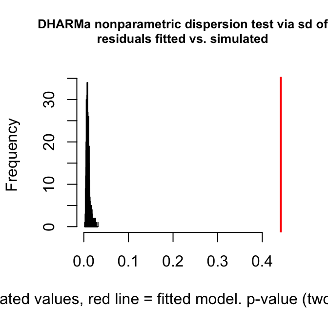

```
    DHARMa nonparametric dispersion test via sd of residuals fitted vs.
    simulated

data:  simulationOutput
dispersion = 48.199, p-value < 2.2e-16
alternative hypothesis: two.sided
```

```r
# 1. Simulate residuals
sim_pois_res <- simulateResiduals(fittedModel = poiss_reg_model, n = 1000)

# 2. Test for dispersion
testDispersion(sim_pois_res)
```

```
qu = 0.25, log(sigma) = -2.941789 : outer Newton did not converge fully.
```

```
qu = 0.25, log(sigma) = -2.915169 : outer Newton did not converge fully.
```

```
qu = 0.25, log(sigma) = -2.999691 : outer Newton did not converge fully.
```

```
qu = 0.75, log(sigma) = -3.59874 : outer Newton did not converge fully.
```

[figure not shown]

```r
# Plot diagnostic plots
plot(sim_pois_res)
```

# Plotting the Poisson Regression

Even though the model is a poor fit, we can visualize its prediction.

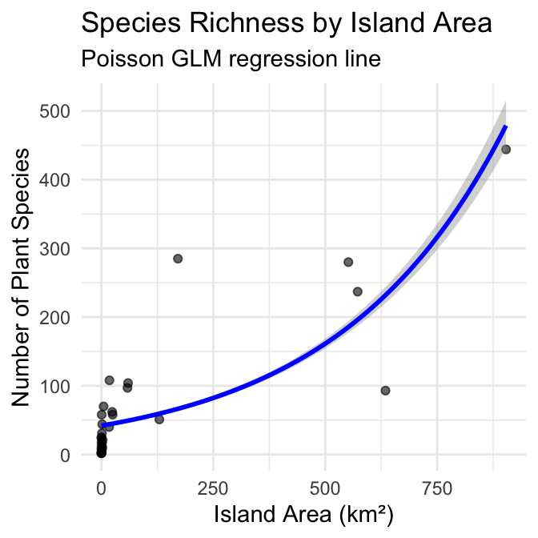

```r
ggplot(g_df, aes(x = area, y = spp)) +
  geom_point(alpha = 0.6) +
  geom_smooth(method = "glm",
              method.args = list(family = "poisson"),
              se = TRUE,
              color = "blue") +
  labs(title = "Species Richness by Island Area",
       subtitle = "Poisson GLM regression line",
       x = "Island Area (km²)",
       y = "Number of Plant Species") +
  theme_minimal()
```

# Negative Binomial GLM Regression

Used to handle overdispersed count data.

The negative binomial model includes a dispersion parameter (theta) to account for the variance being larger than the mean.

```r
nb_reg_model <- glm.nb(spp ~ area, data = g_df)
summary(nb_reg_model)
```

```
Call:
glm.nb(formula = spp ~ area, data = g_df, init.theta = 1.098629663,
    link = log)

Coefficients:
             Estimate Std. Error z value Pr(>|z|)
(Intercept) 3.6082304  0.1987610   18.15  < 2e-16 ***
area        0.0033531  0.0007672    4.37 1.24e-05 ***
---
Signif. codes:  0 '***' 0.001 '**' 0.01 '*' 0.05 '.' 0.1 ' ' 1

(Dispersion parameter for Negative Binomial(1.0986) family taken to be 1)

    Null deviance: 55.178  on 28  degrees of freedom
Residual deviance: 32.695  on 27  degrees of freedom
AIC: 295.08

Number of Fisher Scoring iterations: 1

              Theta:  1.099
          Std. Err.:  0.271

 2 x log-likelihood:  -289.083
```

# NB Assumption Diagnostics (DHARMa)

[figure not shown]

```r
# 1. Simulate residuals
nb_sim_reg_res <- simulateResiduals(fittedModel = nb_reg_model)

# 2. Plot the diagnostics
plot(nb_sim_reg_res)
```

# Overdispersion Check

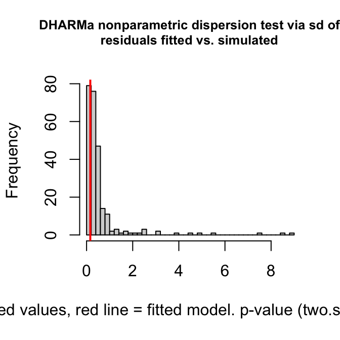

```
    DHARMa nonparametric dispersion test via sd of residuals fitted vs.
    simulated

data:  simulationOutput
dispersion = 0.27162, p-value = 0.488
alternative hypothesis: two.sided
```

```r
testDispersion(nb_sim_reg_res)
```

# ANOVA GLM Negative Binomial

We again use a Likelihood Ratio (LR) test to get the overall p-value for the area predictor.

```r
# Get the overall Anova (Type III Likelihood Ratio test)
nb_reg_anova <- Anova(nb_reg_model, type = "III", test = "LR")

print(nb_anova)
```

[output not shown]

# Plotting the Negative Binomial Regression

This plot shows the fitted line from our final, best-fitting model.

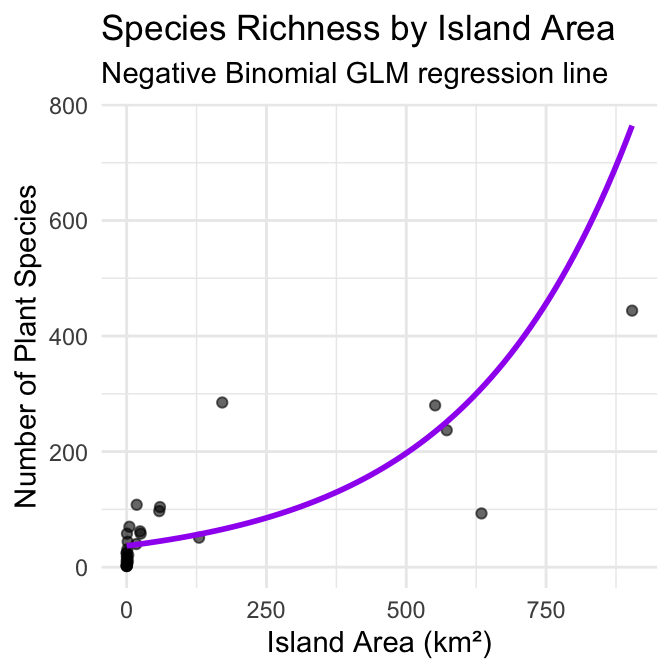

```r
ggplot(g_df, aes(x = area, y = spp)) +
  geom_point(alpha = 0.6) +
  geom_smooth(method = "glm.nb",
              se = FALSE,
              color = "purple") +
  labs(title = "Species Richness by Island Area",
       subtitle = "Negative Binomial GLM regression line",
       x = "Island Area (km²)",
       y = "Number of Plant Species") +
  theme_minimal()
```

# Logistic Regression

Logistic regression is a GLM used when the response variable is binary (e.g., dead/alive, present/absent). It models the probability of the response being “1” (success) given predictor values.

Let’s examine the simple logistic regression model:

$$\pi(x) = \frac{e^{\beta_0 + \beta_1 x}}{1 + e^{\beta_0 + \beta_1 x}}$$

- Where:
  - $\pi(x)$ is the probability that Y = 1 given X = x
  - $\beta_0$ is the intercept
  - $\beta_1$ is the slope (rate of change in $\pi(x)$ for a unit change in X)

To linearize this relationship, we use the logit link function:

$$g(x) = \log\left(\frac{\pi(x)}{1-\pi(x)}\right) = \beta_0 + \beta_1 x$$

This transforms the probability (which is bounded between 0 and 1) to a linear function that can range from -∞ to +∞.

# Example: Lizard Presence on Islands

Based on the example from Polis et al. (1998), we’ll model the presence/absence of lizards (*Uta*) on islands in the Gulf of California based on perimeter/area ratio.

```r
set.seed(123)
island_data <- data.frame(
  island_id = 1:30,
  pa_ratio = seq(5, 70, length.out = 30),
  uta_present = c(rep(1, 10),
                  rbinom(10, 1, prob = 0.5),  # Mixed outcomes in middle
                  rep(0, 10)))%>%
  mutate(uta_present_factor = factor(uta_present, levels = c(0, 1),
         labels = c("Absent", "Present")))
```

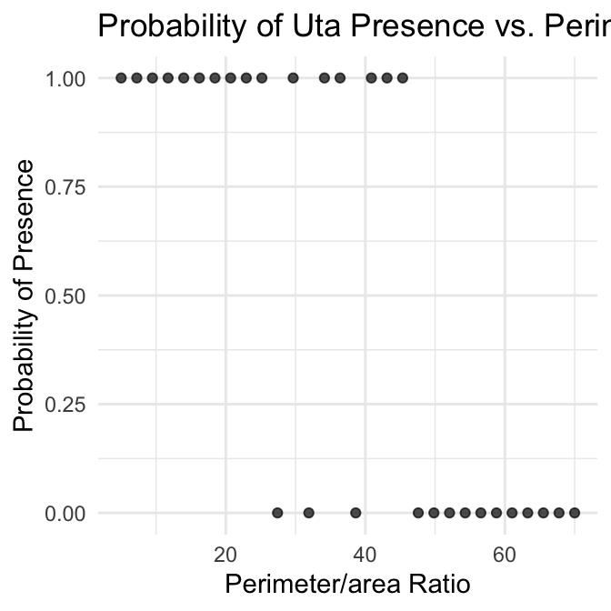

```r
ggplot() +
  # Add jittered points for observed data
  geom_point(data = island_data,
              aes(x = pa_ratio, y = uta_present),
              position = position_dodge2(width=.1), alpha = 0.7) +
  labs(title = "Probability of Uta Presence vs. Perimeter/area Ratio",
       x = "Perimeter/area Ratio",
       y = "Probability of Presence") +
  scale_y_continuous(limits = c(0, 1)) +
  theme_minimal()
```

# Example: Lizard Presence on Islands

Based on the example from Polis et al. (1998), we’ll model the presence/absence of lizards (*Uta*) on islands in the Gulf of California based on perimeter/area ratio.

```r
# Fit the logistic regression model
lizard_model <- glm(uta_present ~ pa_ratio,
                    data = island_data,
                    family = binomial(link = "logit"))

# Model summary
summary(lizard_model)
```

```
Call:
glm(formula = uta_present ~ pa_ratio, family = binomial(link = "logit"),
    data = island_data)

Coefficients:
            Estimate Std. Error z value Pr(>|z|)
(Intercept)   5.9374     2.1297   2.788  0.00530 **
pa_ratio     -0.1493     0.0517  -2.887  0.00388 **
---
Signif. codes:  0 '***' 0.001 '**' 0.01 '*' 0.05 '.' 0.1 ' ' 1

(Dispersion parameter for binomial family taken to be 1)

    Null deviance: 41.455  on 29  degrees of freedom
Residual deviance: 19.090  on 28  degrees of freedom
AIC: 23.09

Number of Fisher Scoring iterations: 6
```

# Lizard Example: Visualization and Testing

Let’s visualize the data and the fitted model:

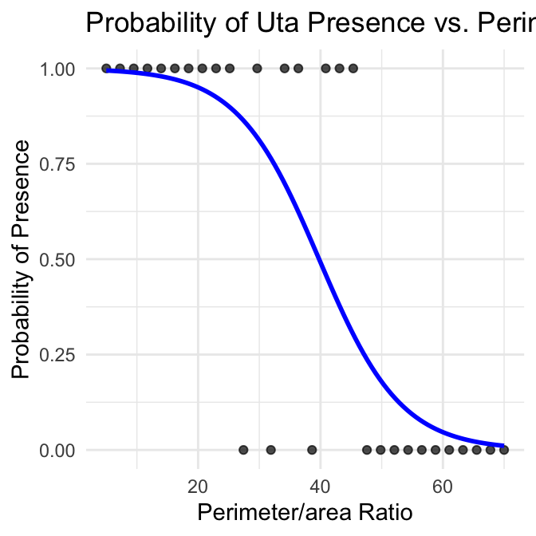

```r
#| paged-print: false
# Create a dataframe for predictions
pred_data <- data.frame(
  pa_ratio = seq(min(island_data$pa_ratio),
                max(island_data$pa_ratio),
                length.out = 100)
)

# Get predicted probabilities
pred_data$prob <- predict(lizard_model,
                         newdata = pred_data,
                         type = "response")

# Plot
ggplot() +
  # Add jittered points for observed data
  geom_point(data = island_data,
              aes(x = pa_ratio, y = uta_present),
              position = position_dodge2(width=.1), alpha = 0.7) +
  # Add predicted probability curve
  geom_line(data = pred_data,
            aes(x = pa_ratio, y = prob),
            color = "blue", size = 1) +
  # Add confidence intervals (optional)
  labs(title = "Probability of Uta Presence vs. Perimeter/area Ratio",
       x = "Perimeter/area Ratio",
       y = "Probability of Presence") +
  scale_y_continuous(limits = c(0, 1)) +
  theme_minimal()
```

We want to test the null hypothesis that β₁ = 0, meaning there’s no relationship between P/A ratio and lizard presence.

There are two common ways to test this hypothesis:

1. **Wald test**: Tests if the parameter estimate divided by its standard error differs significantly from zero
2. **Likelihood ratio test**: Compares the fit of the full model to a reduced model without the predictor variable

```r
reduced_model <- glm(uta_present ~ 1,
                     data = island_data,
                     family = binomial(link = "logit"))
anova(reduced_model, lizard_model, test = "Chisq")
```

```
Analysis of Deviance Table

Model 1: uta_present ~ 1
Model 2: uta_present ~ pa_ratio
  Resid. Df Resid. Dev Df Deviance    Pr(>Chi)
1        29     41.455
2        28     19.090  1   22.365 0.000002254 ***
---
Signif. codes:  0 '***' 0.001 '**' 0.01 '*' 0.05 '.' 0.1 ' ' 1
```

# Interpreting the Odds Ratio

### Working with Odds Ratios

The odds ratio represents how the odds of the event (e.g., lizard presence) change with a unit increase in the predictor.

```r
coef_lizard <- coef(lizard_model)[2]  # Extract slope coefficient
odds_ratio <- exp(coef_lizard)
ci <- exp(confint(lizard_model, "pa_ratio"))
cat("Odds Ratio:", round(odds_ratio, 3), "\n\n",
"95% CI:", round(ci[1], 3), "to", round(ci[2], 3), "\n")
```

```
Odds Ratio: 0.861

 95% CI: 0.753 to 0.932
```

```r
# This function is specifically for model parameters
model_parameters(lizard_model, exponentiate = TRUE)
```

```
Parameter   | Odds Ratio |     SE |            95% CI |     z |     p
---------------------------------------------------------------------
(Intercept) |     378.94 | 807.02 | [14.47, 94371.40] |  2.79 | 0.005
pa ratio    |       0.86 |   0.04 | [ 0.75,     0.93] | -2.89 | 0.004
```

```
Uncertainty intervals (profile-likelihood) and p-values (two-tailed)
  computed using a Wald z-distribution approximation.
```

This gives you the odds ratio (in the estimate column) and the exponentiated CIs (conf.low, conf.high) for all terms in your model, all in one clean table.

```r
library(broom)

# This one function does everything
tidy(lizard_model, exponentiate = TRUE, conf.int = TRUE)
```

```
# A tibble: 2 × 7
  term        estimate std.error statistic p.value conf.low conf.high
  <chr>          <dbl>     <dbl>     <dbl>   <dbl>    <dbl>     <dbl>
1 (Intercept)  379.       2.13        2.79 0.00530   14.5   94371.
2 pa_ratio       0.861    0.0517     -2.89 0.00388    0.753     0.932
```